# Satellite image comparison

```r
library(tidyverse)
library(here)
library(fs)
library(janitor)
library(lubridate)
library(tsibble)
library(splines)
library(zoo)
library(kableExtra)
library(GGally)
library(ggpubr)
library(broom)
```

Not the most elegant solution to download each time series into a seperate csv, but working with what I’ve got.

```r
# modis polygon
ts_modis <- dir_ls(here("data/google_earth_engine/modis_grid_cells"), regexp = ".csv$") %>%
  map_df(read_csv, id = "filename", col_types = cols())

# bloom polygon
ts_custom <- dir_ls(here("data/google_earth_engine/custom_polygon"), regexp = ".csv$") %>%
  map_df(read_csv, id = "filename", col_types = cols())

# bloom polygon pix count
ts_custom_count <- dir_ls(here("data/google_earth_engine/custom_polygon/count"), regexp = "count.csv$") %>%
  map_df(read_csv, id = "filename", col_types = cols())

# glacier polygon
ts_glims <- dir_ls(here("data/google_earth_engine/glimsGeom"), regexp = ".csv$") %>%
  map_df(read_csv, id = "filename", col_types = cols())

# histogram of RGND during peak bloom week
hist <- dir_ls(here("data/google_earth_engine/hist/"), regexp = "*hist.csv$") %>%
  map_df(read_csv, id = "filename", col_types = cols())

# wx
wx <- dir_ls(here("data/google_earth_engine/wx"), regexp = "*wx.csv$") %>%
  map_df(read_csv, id = "filename", col_types = cols())
```

Coefs for biomass and albedo regression models

```r
biomass_coefs <- read_csv(here("data/abundance_coefs.csv"))
albedo_coefs <- read_csv(here("data/albedo_coefs.csv")) %>%
  add_column("response"= "albedo") # add column to match biomass_coefs
```

# tidy

```r
# parse site name, date
my_tidy <- function(df){
  df %>%
    clean_names() %>%
    mutate(site = filename %>% basename() %>% str_remove(".csv") %>% str_split_i("_",1),
           date = mdy(system_time_start))
}

# parse platform name, apply cloudmask
ts_tidy <- function(df){
  df %>%
     mutate(platform = basename(filename) %>%
              str_split_i("_", 2) %>%
              str_remove(".csv"),
         rgnd = if_else(is.na(rgnd), rgnd_cloudmasked, rgnd)) %>%
  select(platform, site, date, rgnd, albedo)
}


ts_modis_wide <- ts_modis %>%
  my_tidy() %>%
  ts_tidy()

ts_custom_wide_unfilt <- ts_custom %>%
  my_tidy() %>%
  ts_tidy()

ts_custom_count_wide <- ts_custom_count %>%
  my_tidy() %>%
  mutate(platform = basename(filename) %>%
              str_split_i("_", 2) %>%
              str_remove(".csv"),
         date = mdy(system_time_start),
         .keep = "unused") %>%
  rename(count  = rgnd_cloudmasked) %>%
  select(platform, site, date, count)


ts_glims_wide <- ts_glims %>%
  my_tidy() %>%
  ts_tidy()

hist_clean <- hist %>%
  clean_names() %>%
  mutate(site = basename(filename) %>% str_split_i("_", 1), .keep = "unused") %>%
  mutate(type = case_when(str_detect(site, "Algae")~"algae",
                          TRUE ~ as.character(site))) %>%
  rename(rgnd = band_value, count = true_rgnd_count) %>%
  select(type, rgnd, count) %>%
  drop_na(count)

wx_clean <- wx %>%
  my_tidy() %>%
  select(-filename, -system_time_start) %>%
  pivot_longer(-site:-date, values_drop_na =TRUE) %>%
  pivot_wider()
```

# n pix per image

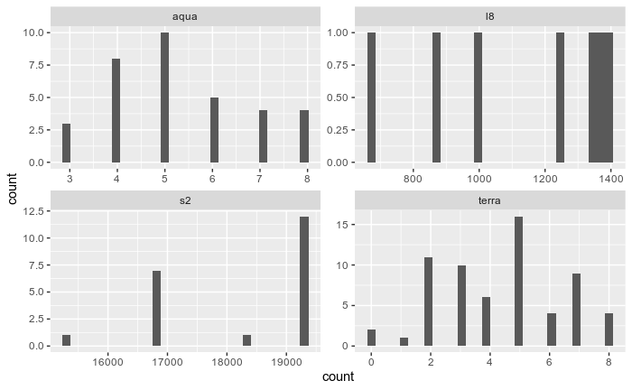

```r
ts_custom_wide_unfilt %>%
  inner_join(ts_custom_count_wide) %>%
  ggplot(aes(count)) +
  geom_histogram() +
  facet_wrap(vars(platform), scales = "free")
```

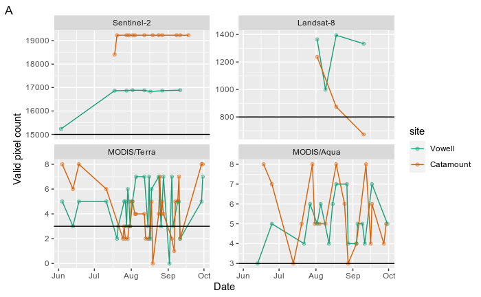

```r
ppdat <- ts_custom_wide_unfilt %>%
  inner_join(ts_custom_count_wide) %>%
  mutate(platform = platform %>% fct_recode("MODIS/Aqua"="aqua","Sentinel-2"="s2", "Landsat-8"="l8", "MODIS/Terra"="terra") %>% fct_relevel("Sentinel-2", "Landsat-8", "MODIS/Terra"),
         site = site %>% fct_relevel("vowell") %>% fct_recode("Catamount"="cat", "Vowell"="vowell"))
ppdat %>%
  ggplot(aes(y = count, x = date, color = site)) +
  geom_point(alpha = 0.4) +
  geom_line()+
  facet_wrap(vars(platform), scales = "free_y") +
  scale_colour_brewer(palette = "Dark2")+
  labs(y = "Valid pixel count", x = "Date", tag="A") +
  geom_hline(aes(yintercept = 3), data = ppdat %>% filter(platform %>% str_detect("MODIS"))) +
  geom_hline(aes(yintercept = 15000), data = ppdat %>% filter(platform =="Sentinel-2")) +
  geom_hline(aes(yintercept = 800), data = ppdat %>% filter(platform =="Landsat-8"))
```

```r
count(ts_custom_wide_unfilt, platform)
```

| platform | n |
| --- | --- |
| aqua | 34 |
| aquaSnow | 66 |
| l8 | 7 |
| s2 | 21 |
| terra | 63 |
| terraSnow | 85 |

```r
modis_thresh <- 3
s2_thresh <- 15000
l8_thresh <- 800

ts_custom_wide <-
  ts_custom_wide_unfilt %>%
  left_join(ts_custom_count_wide) %>%
  left_join(tribble(
    ~platform, ~thresh,
    "l8",l8_thresh,
    "s2",s2_thresh,
    "terra",modis_thresh,
    "aqua", modis_thresh
  )) %>% #count(platform) # check before
  # hack to filter by thresh without discarding the time series that don't have count/thresh data
  filter(if_else(!is.na(count), count>=thresh, TRUE)) #%>% count(platform) # check after, only should remove S2/L8/Terra
nrow(ts_custom_wide)
```

```
[1] 261
```

```r
count(ts_custom_wide, platform)
```

| platform | n |
| --- | --- |
| aqua | 34 |
| aquaSnow | 66 |
| l8 | 6 |
| s2 | 21 |
| terra | 49 |
| terraSnow | 85 |

# n obs per platform

```r
n_img_kable <- ts_custom_wide %>%
  group_by(site, platform) %>%
  summarise(n_images = n()) %>%
  ungroup() %>%
  filter(platform!="terraSnow", platform!="aquaSnow") %>%
  mutate(platform = platform %>% fct_recode("Landsat-8"="l8",
                                            "Sentinel-2"="s2",
                                            "MODIS/Terra"="terra",
                                            "MODIS/Aqua"="aqua")) %>%
  pivot_wider(names_from = site, values_from = n_images) %>%
  kbl(caption = "B. Number of cloud-free satellite images per site used in analysis", col.names = c("Platform", "Catamount", "Vowell")) %>%
  kable_classic(full_width = F, html_font = "Cambria")
```

```
argument.
```

```r
n_img_kable %>%
  save_kable(here("figs/n_images_table.pdf"))
```

```
Note that HTML color may not be displayed on PDF properly.
```

N images July 5 - Sept 1

```r
ts_custom_wide %>%
  filter(date>"2020-07-05", date<"2020-09-01") %>%
  group_by(site, platform) %>%
  summarise(n_images = n()) %>%
  ungroup() %>%
  filter(platform=="s2")
```

```
argument.
```

| site | platform | n_images |
| --- | --- | --- |
| cat | s2 | 10 |
| vowell | s2 | 6 |

# fig6 plot

```r
# make pretty for plotting
plot_dat_4 <- ts_custom_wide %>%
  filter(platform %in% c("s2", "l8", "terra", "aqua"),
         # remove sept 8 for catamount, looks like snow buried the algae on this date. Our index not calibrated for lightly buried snow algae
         !(platform=="s2" & site=="cat" & date==ymd("2020-09-08")),
         # full polygon was set as "not snow" and therefore set RGND=0
         !(platform=="aqua" & site == "vowell" & date==ymd("2020-07-22")),
         # all but one pixels set as not snow, only 1 valid RGND pixel,
         ) %>%
  mutate(platform = platform %>%
           fct_recode("Sentinel-2"="s2",
                      "Landsat-8"="l8",
                      "MODIS/Terra"="terra",
                      "MODIS/Aqua"="aqua") %>%
           fct_relevel(c("Sentinel-2", "Landsat-8", "MODIS/Terra")),
         site = site %>% fct_relevel("vowell")) %>%
  mutate(site = fct_recode(site, "Vowell"="vowell","Catamount"="cat")) %>%
  dplyr::rename(Platform = platform)
plot_dat_4$Platform %>% levels()
```

```
[1] "Sentinel-2"  "Landsat-8"   "MODIS/Terra" "MODIS/Aqua"
```

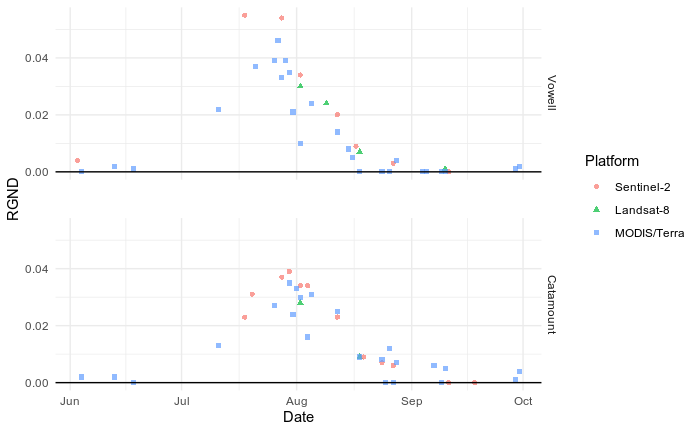

```r
plot_dat <- plot_dat_4 %>% filter(Platform!="MODIS/Aqua")

gg_color_hue <- function(n) {
  hues = seq(15, 375, length = n + 1)
  hcl(h = hues, l = 65, c = 100)[1:n]
}

p1 <- plot_dat %>%
  ggplot(aes(x = date, y = rgnd, color = Platform, shape = Platform)) +
  facet_grid(rows = vars(site)) +
  geom_point(alpha =0.7) +
  labs(x = "Date", y = "RGND") +
  theme_minimal() +
  geom_hline(yintercept = 0) +
  theme(panel.spacing = unit(2, "lines"))
p1
```

## sentinel linear interpolation

```r
s2_interp <- plot_dat %>%
  filter(Platform=="Sentinel-2",
         # just July-Aug data
         date >= "2020-07-01",
         date <= "2020-09-12") %>%
  # set 0 on Jul 1 and Sept 1
  bind_rows(tribble(
    ~site, ~date, ~rgnd,
    "Catamount", ymd("2020-07-05"), 0,
    "Catamount", ymd("2020-09-01"), 0,
    "Vowell", ymd("2020-07-05"), 0,
    "Vowell", ymd("2020-09-01"), 0
  )) %>%
  # convert to tsibble to use handy fill_gaps()
  as_tsibble(key = site) %>%
  # make missing values explicit NA
  fill_gaps() %>%
  # linear interpolate NA
  mutate(rgnd = zoo::na.approx(rgnd)) %>%
  as_tibble() %>%
  # add stuff back in for plotting
  mutate(Platform="Sentinel-2",
         site = site %>% fct_relevel("Vowell"))
```

```
Using `date` as index variable.
```

## export final plot

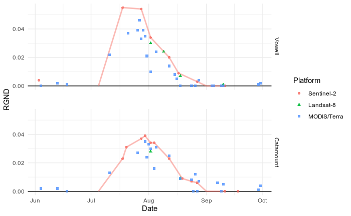

```r
p1 +
  # geom_line(stat="smooth", method = "loess", data= curve_dat, alpha = 0.5, size = 1, color = "purple")
  geom_line(data= s2_interp, alpha = 0.5, size = 1, color = gg_color_hue(3)[1]) +
  # re plot points, so the points are on top of the line
  geom_point(alpha = 0.7)
```

```r
ggsave(here("figs/figs_v2/7_rgnd_ts/satellite_time_series.pdf"), height = 5, width = 7)
```

# Compare satellite RGND w/in 5 day window

## pairs plot

```r
date_bins <- plot_dat_4 %>%
  # bin time into discrete 4 day intervals
  mutate(date_bin = date %>% yday() %>% cut_width(width=5)) %>%
  group_by(Platform, site, date_bin) %>%
  summarise(rgnd = mean(rgnd)) %>%
  ungroup() %>%
  pivot_wider(names_from = "Platform", values_from = "rgnd")
# check that cut_width works as expected
date_bins %>%
  distinct(date_bin) %>%
  arrange(date_bin)
```

| date_bin |
| --- |
| [152,158] |
| (162,168] |
| (168,172] |
| (172,178] |
| (192,198] |
| (198,202] |
| (202,208] |
| (208,212] |
| (212,218] |
| (218,222] |

[output cut: 9 more lines]

Comparison of mean values for each 5 day time interval

[output not shown]

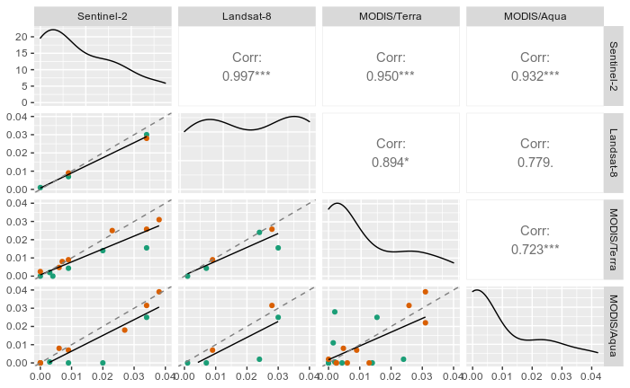

```r
my_fn <- function(data, mapping, ...){
  ggplot(data = data, mapping = mapping) +
    geom_point(aes(color = site)) +
    geom_line(stat="smooth", method="lm", ...) +
    scale_x_continuous(limits = c(0,0.04))+
    scale_y_continuous(limits = c(0,0.04))+
    scale_colour_brewer(palette = "Dark2")+
    geom_abline(slope = 1, intercept = 0, linetype="dashed", color = "grey50")
}

date_bins %>%
  ggpairs(columns = 3:6,
          lower = list(continuous = my_fn))
```

```r
mod_s2_ratio <- date_bins %>%
  clean_names() %>%
  rowwise() %>% # a special form of grouping
  mutate(mean_modis = mean(c(modis_terra, modis_aqua), na.rm=T),
         mod_s2_ratio = mean_modis/sentinel_2) %>%
  ungroup()
mod_s2_ratio
```

| site | date_bin | sentinel_2 | landsat_8 | modis_terra | modis_aqua | mean_modis | mod_s2_ratio |
| --- | --- | --- | --- | --- | --- | --- | --- |
| Vowell | [152,158] | 0.004 | NA | 0.000000000 | NA | 0.000000000 | 0.0000000 |
| Vowell | (198,202] | 0.055 | NA | NA | NA | NaN | NaN |
| Vowell | (208,212] | 0.054 | NA | 0.038400000 | 0.0420 | 0.040200000 | 0.7444444 |
| Vowell | (212,218] | 0.034 | 0.030 | 0.015500000 | 0.0250 | 0.020250000 | 0.5955882 |
| Vowell | (222,228] | 0.020 | NA | 0.014000000 | 0.0000 | 0.007000000 | 0.3500000 |
| Vowell | (228,232] | 0.009 | 0.007 | 0.004333333 | 0.0000 | 0.002166667 | 0.2407407 |
| Vowell | (238,242] | 0.003 | NA | 0.002000000 | 0.0005 | 0.001250000 | 0.4166667 |
| Vowell | (252,258] | 0.000 | 0.001 | 0.000000000 | 0.0000 | 0.000000000 | NaN |
| Catamount | (198,202] | 0.027 | NA | NA | 0.0180 | 0.018000000 | 0.6666667 |
| Catamount | (208,212] | 0.038 | NA | 0.031000000 | 0.0390 | 0.035000000 | 0.9210526 |

[output cut: 26 more lines]

```r
mod_s2_ratio %>%
  filter(!(is.na(mod_s2_ratio)), !(is.infinite(mod_s2_ratio))) %>%
  summarise(mean(mod_s2_ratio), sd(mod_s2_ratio))
```

| mean(mod_s2_ratio) | sd(mod_s2_ratio) |
| --- | --- |
| 0.689098 | 0.3533278 |

```r
NA
```

```r
# ppa <- date_bins %>%
#   ggplot(aes(y = `Sentinel-2`, x = `MODIS/Terra`)) +
#   geom_point(aes(color = site), size = 2.5) +
#   lims(x = c(0, 0.04), y = c(0, 0.04)) +
#   geom_smooth(method = "lm", se=FALSE) +
#   theme_minimal() +
#   labs(y = "Sentinel-2 RGND", x = "MODIS/Terra RGND", tag = "A") +
#   geom_abline(slope = 1, intercept = 0, linetype="dashed", color = "grey50") +
#   scale_colour_brewer(palette = "Dark2")
# ppa
#
# ppb <- date_bins %>%
#   ggplot(aes(y = `Sentinel-2`, x = `Landsat-8`)) +
#   geom_point(aes(color = site), size = 2.5) +
#   lims(x = c(0, 0.04), y = c(0, 0.04)) +
#   geom_smooth(method = "lm", se=FALSE) +
#   theme_minimal() +
#   labs(y = "Sentinel-2 RGND", x = "Landsat-8", tag = "B") +
#   geom_abline(slope = 1, intercept = 0, linetype="dashed", color = "grey50") +
#   scale_colour_brewer(palette = "Dark2")
# ppb
#
# ppc <- date_bins %>%
#   ggplot(aes(y = `Landsat-8`, x = `MODIS/Terra`)) +
#   geom_point(aes(color = site), size = 2.5) +
#   lims(x = c(0, 0.04), y = c(0, 0.04)) +
#   geom_smooth(method = "lm", se=FALSE) +
#   theme_minimal() +
#   labs(y = "Landsat-8 RGND", x = "MODIS/Terra RGND", tag = "C") +
#   geom_abline(slope = 1, intercept = 0, linetype="dashed", color = "grey50") +
#   scale_colour_brewer(palette = "Dark2")
# ppc
#
# legend <- cowplot::get_legend(ppa)
# ggarrange(ppa + theme(legend.position = "none"), ppb + theme(legend.position = "none"), ppc + theme(legend.position = "none"), legend)
```

```r
# ggsave(here("figs/rgnd_compare.png"))
```

## peak bloom boxplot

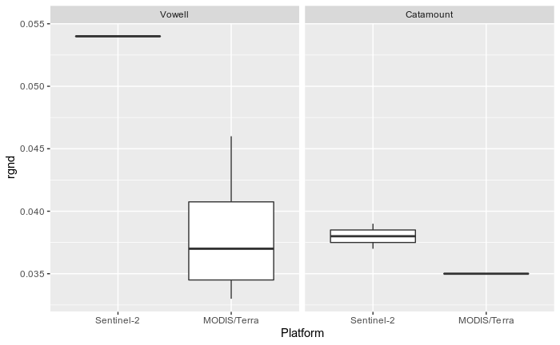

```r
peak_yday <- yday(ymd('2020-07-28'))
# i can see this date bin is (208,212], thats Jul 27 -Jul 30


plot_dat %>%
  filter(date>ymd("2020-07-26"), date <= ymd("2020-07-30")) %>%
  ggplot(aes(x = Platform, y = rgnd)) +
  geom_boxplot() +
  facet_wrap(vars(site))
```

defining “peak week” as Jul 27 -Jul 30

# algae stats during peak week

## bloom polygon

Apply regression estimates:

```r
# from GEE
bloom_polygon_area <- tribble(
  ~site, ~area_m2,
  "vowell", 1684302,
  "cat", 1918716
)
```

[output not shown]

Compute mean values

```r
bloom_polygon_stats %>%
  mutate(across(vowell_value:cat_se, as.numeric)) %>%
  pivot_longer(-name, names_to = "s", values_drop_na = TRUE) %>%
  separate(s, into = c("site", "stat")) %>%
  group_by(name, stat) %>%
  summarise(mean = mean(value)) %>%
  pivot_wider(names_from= "stat", values_from = "mean")
```

| name | value | se |
| --- | --- | --- |
| area_m2 | 1.800e+06 | NA |
| cell_area_percent_cov | 1.575e+00 | 1.940e-01 |
| bil_cells_per_m2 | 5.005e-02 | 7.900e-03 |
| delta_albedo | -3.855e-02 | 7.530e-03 |
| rgnd | 4.700e-02 | NA |
| tn_mg_m2 | 1.715e+01 | 2.230e+00 |
| toc_g_m2 | 7.435e-01 | 1.015e-01 |
| total_cells_10^9 | 8.810e+04 | 1.400e+04 |
| total_tn_kg | 3.055e+01 | 3.975e+00 |
| total_toc_kg | 1.320e+03 | 1.805e+02 |

```r
bloom_kable %>%
  save_kable(here("figs/bloom_poly_stats_table.pdf"))
```

```
Note that HTML color may not be displayed on PDF properly.
```

```bash
# the density parameter must come before the input file
convert \
  -density 300 \
  ../figs/bloom_poly_stats_table.pdf \
  -sharpen 0x1.0 \
  -quality 100 \
  ../figs/bloom_poly_stats_table.png
```

### compare w MODIS albedo

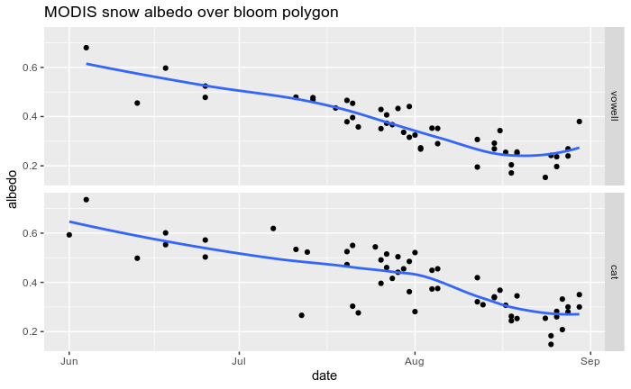

```r
ts_custom_wide %>%
  filter(date<"2020-09-01") %>%
  mutate(site = site %>% fct_relevel("vowell")) %>%
  drop_na(albedo) %>%
  ggplot(aes(x = date, y = albedo)) +
  geom_point() +
  facet_grid(rows = vars(site)) +
  geom_smooth(se = FALSE) +
  ggtitle("MODIS snow albedo over bloom polygon")
```

Extract LOESS estimates

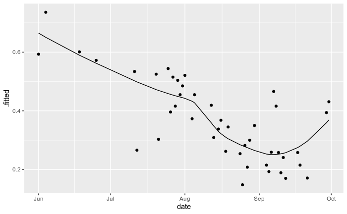

```r
vowell_dat <- ts_custom_wide %>% filter(platform =="terraSnow", site=="vowell")
cat_dat <- ts_custom_wide %>% filter(platform =="terraSnow", site=="cat")

dates_in_summer <- ts_custom_wide %>% distinct(date)
ydays_in_summer <- dates_in_summer %>% mutate(date = yday(date)) %>% pull()

vowell_mod <- loess(albedo ~ yday(date), data = vowell_dat)
cat_mod <- loess(albedo ~ yday(date), data = cat_dat)

vowell_aug <- vowell_mod %>% broom::augment(vowell_dat)
cat_aug <- cat_mod %>% augment(cat_dat)

cat_aug %>%
  ggplot(aes(x = date)) +
  geom_line(aes(y=.fitted)) +
  geom_point(aes(y = albedo))
```

```r
vowell_grid <- yday(ymd("2020-07-05")):yday(ymd("2020-07-18"))
cat_grid <- yday(ymd("2020-07-05")):yday(ymd("2020-07-30"))

vowell_pred <- vowell_mod %>% predict(vowell_grid)
cat_pred <- cat_mod %>% predict(cat_grid)

vowell_diff <- vowell_pred[1] - vowell_pred[vowell_pred==min(vowell_pred)]
cat_diff <- cat_pred[1] - cat_pred[cat_pred==min(cat_pred)]
vowell_diff
```

```
[1] 0.06923968
```

```r
cat_diff
```

```
[1] 0.07760101
```

## glacier polygon

```r
# from GEE
glacier_polygon_area <- tribble(
  ~site, ~area_m2,
  "vowell", 6.03739e6,
  "cat", 5.84705e6
)

glacier_polygon_stats <- ts_glims_wide %>%
  get_max_s2_rgnd() %>%
  estimate_bloom_stats(polygon_area_df = glacier_polygon_area)
glims_kable <- glacier_polygon_stats %>% mutate(name=name %>% fct_recode(
    "RGND"="rgnd",
    "Glacier area (m^2)" = "area_m2",
    "Cell area density (10^9 cells/m^2)" ="bil_cells_per_m2",
    "Cell area % cover" ="cell_area_percent_cov",
    "TOC (g/m^2)" = "toc_g_m2",
    "TN (mg/m^2)" = "tn_mg_m2",
    "Delta albedo" = "delta_albedo",
    "Total cells (10^9)"="total_cells_10^9",
    "Total TOC (kg)" = "total_toc_kg",
    "Total TN (kg)" = "total_tn_kg"
  )) %>%
  kbl(caption = "B. Glacier polygon averages", col.names = c("", "Vowell", "Vowell SE", "Catamount", "Catamount SE")) %>%
  kable_classic(full_width = F, html_font = "Cambria")
glims_kable
```

B. Glacier polygon averages

|  | Vowell | Vowell SE | Catamount | Catamount SE |
| --- | --- | --- | --- | --- |
| RGND | 1.90e-02 | NA | 2.00e-02 | NA |
| Glacier area (m^2) | 6.04e+06 | NA | 5.85e+06 | NA |
| Cell area density (10^9 cells/m^2) | 7.94e-03 | 1.26e-03 | 8.80e-03 | 1.39e-03 |
| Cell area % cover | 2.50e-01 | 3.08e-02 | 2.77e-01 | 3.41e-02 |
| TOC (g/m^2) | 3.00e-01 | 4.09e-02 | 3.16e-01 | 4.31e-02 |
| TN (mg/m^2) | 6.93e+00 | 9.02e-01 | 7.29e+00 | 9.50e-01 |
| Delta albedo | -1.56e-02 | 3.04e-03 | -1.64e-02 | 3.20e-03 |
| Total cells (10^9) | 4.80e+04 | 7.60e+03 | 5.15e+04 | 8.15e+03 |
| Total TOC (kg) | 1.81e+03 | 2.47e+02 | 1.85e+03 | 2.52e+02 |
| Total TN (kg) | 4.18e+01 | 5.45e+00 | 4.26e+01 | 5.55e+00 |

```r
glims_kable %>%
  save_kable(here("figs/glims_poly_stats_table.pdf"))
```

```
Note that HTML color may not be displayed on PDF properly.
```

```bash
# the density parameter must come before the input file
convert \
  -density 300 \
  ../figs/glims_poly_stats_table.pdf \
  -sharpen 0x1.0 \
  -quality 100 \
  ../figs/glims_poly_stats_table.png
```

### compare with MODIS snow albedo

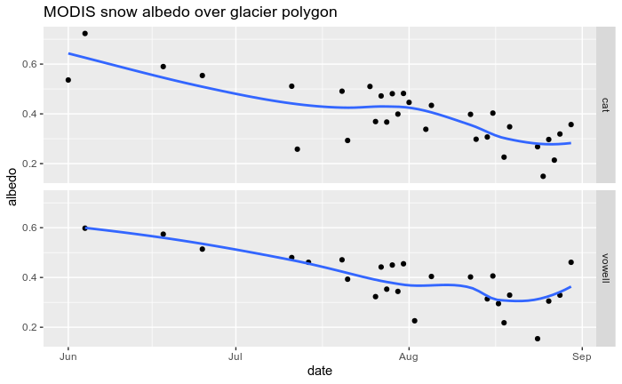

```r
ts_glims_wide %>%
  filter(date<"2020-09-01") %>%
  drop_na(albedo) %>%
  ggplot(aes(x = date, y = albedo)) +
  geom_point() +
  facet_grid(rows = vars(site)) +
  geom_smooth(se = FALSE) +
  ggtitle("MODIS snow albedo over glacier polygon")
```

# summer radiative forcing

```r
summer_rf <- function(srad_df, delta_albedo_df){
  srad_df %>%
    filter(month(date) %in% c(7,8)) %>%
    select(date, srad) %>%
    left_join(delta_albedo_df, by = "date") %>%
    mutate(rf = srad * delta_albedo,
           rf_se = srad * delta_albedo_se) %>%
    group_by(site) %>%
    summarise(rf_wm2 = mean(rf), rf_se = mean(rf_se))
}
```

Using S2 mean RGND within bloom polygon to estimate July-August RF

```r
# using the interpolated data with assumed start and end points
s2_interp_d_albedo <- s2_interp %>%
  mutate( delta_albedo = get_coef(albedo_coefs, "albedo", estimate) * rgnd,
          delta_albedo_se = get_coef(albedo_coefs, "albedo", std.error) * rgnd) %>%
  select(-albedo)

wx_clean %>%
  select(site, date, srad) %>%
  summer_rf(delta_albedo_df = s2_interp_d_albedo) %>%
  drop_na()
```

| site | rf_wm2 | rf_se |
| --- | --- | --- |
| Vowell | -9.604238 | 1.875195 |
| Catamount | -6.910984 | 1.349347 |

Compute the total energy absorbed by the algae during this time period from DRF

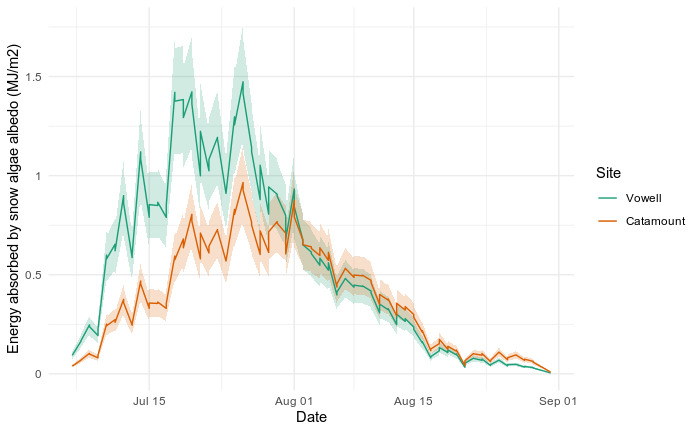

[output not shown]

[output cut: 990 more lines]

The total energy delivered:

| site | name | value | snowmelt_eq_kg | snowdepth_eq_m |
| --- | --- | --- | --- | --- |
| Vowell | sum_algal_energy | 61386961 | 186.02109 | 0.37204219 |
| Vowell | sum_algal_se | 11985599 | 36.32000 | 0.07263999 |
| Vowell | sum_srad | 2501524579 | 7580.37751 | 15.16075503 |
| Catamount | sum_algal_energy | 43590635 | 132.09283 | 0.26418567 |
| Catamount | sum_algal_se | 8510926 | 25.79068 | 0.05158137 |
| Catamount | sum_srad | 2501524579 | 7580.37751 | 15.16075503 |

Convert this per total area?

Computing this another way, taking the averages first and then multiplying srad by delta albedo

```r
# mean summer incoming radiation
mean_summer_srad <- wx_clean %>%
  filter(month(date) %in% c(7,8)) %>%
  group_by(site) %>%
  summarise(mean(srad)) %>%
  mutate(site = site %>% fct_recode("Vowell"="vowell", "Catamount"="cat"))


# mean summer d albedo
s2_interp_d_albedo %>%
  group_by(site) %>%
  summarise(mean(delta_albedo), mean(delta_albedo_se)) %>%
  left_join(mean_summer_srad) %>%
  mutate(srf = `mean(delta_albedo)` * `mean(srad)`,
         srf_se = `mean(delta_albedo_se)` * `mean(srad)`)
```

| site | mean(delta_albedo) | mean(delta_albedo_se) | mean(srad) | srf | srf_se |
| --- | --- | --- | --- | --- | --- |
| Vowell | -0.01822843 | 0.003559041 | 409.5779 | -7.465964 | 1.457705 |
| Catamount | -0.01360145 | 0.002655637 | 402.2879 | -5.471697 | 1.068331 |

# compare RGND time series with different polygons

[output not shown]

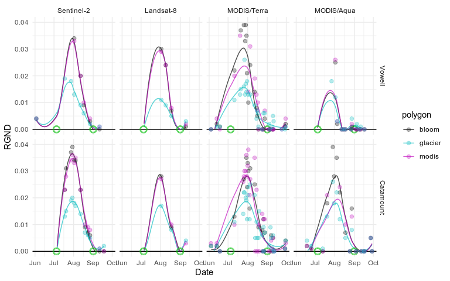

```r
plot_dat2 <- ts_custom_wide %>% add_column(polygon = "bloom") %>%
  bind_rows(ts_modis_wide %>% add_column(polygon = "modis")) %>%
  bind_rows(ts_glims_wide %>% add_column(polygon = "glacier")) %>%
  filter(platform %in% c("s2", "l8", "terra", "aqua"),
         # same filtering criteria as above (duplicated code... not the best approach)
          !(platform=="s2" & site=="cat" & date==ymd("2020-09-08")),
         # full polygon was set as "not snow" and therefore set RGND=0
         !(platform=="aqua" & site == "vowell" & date==ymd("2020-07-22")),
         # discard nonsensical obs-- RGND spike on Sep 30 cannot be due to snow algae, b/c there is no snow.
         !(platform=="aqua" & site == "vowell" & date==ymd("2020-09-30")),
         # discard nonsensical high RGND in early June for aqua, only one pixel, no algae in S2 and L8 this early
         !(platform=="aqua" & site == "vowell" & date<ymd("2020-07-01"))
         ) %>%
  mutate(platform = platform %>%
           fct_recode("Sentinel-2"="s2",
                      "Landsat-8"="l8",
                      "MODIS/Terra"="terra",
                      "MODIS/Aqua"="aqua")) %>%
  mutate(site = site %>% fct_recode("Catamount"="cat", "Vowell"="vowell")) %>%
  # add data for illustrative purposes, set to 0 on Jun 1 where data missing
  bind_rows(tribble(
    ~platform, ~site, ~date, ~rgnd, ~albedo, ~count, ~thresh, ~polygon,
    "Sentinel-2", "Catamount", ymd("2020-07-05"), 0,NA,NA,NA,"bloom",
    "Sentinel-2", "Catamount", ymd("2020-07-05"), 0,NA,NA,NA,"modis",
    "Sentinel-2", "Catamount", ymd("2020-07-05"), 0,NA,NA,NA,"glacier",
    "Sentinel-2", "Vowell", ymd("2020-07-05"), 0,NA,NA,NA,"bloom",
    "Sentinel-2", "Vowell", ymd("2020-07-05"), 0,NA,NA,NA,"modis",
    "Sentinel-2", "Vowell", ymd("2020-07-05"), 0,NA,NA,NA,"glacier",
    "Landsat-8", "Catamount", ymd("2020-07-05"), 0,NA,NA,NA,"bloom",
    "Landsat-8", "Catamount", ymd("2020-07-05"), 0,NA,NA,NA,"modis",
    "Landsat-8", "Catamount", ymd("2020-07-05"), 0,NA,NA,NA,"glacier",
    "Landsat-8", "Vowell", ymd("2020-07-05"), 0,NA,NA,NA,"bloom",
    "Landsat-8", "Vowell", ymd("2020-07-05"), 0,NA,NA,NA,"modis",
    "Landsat-8", "Vowell", ymd("2020-07-05"), 0,NA,NA,NA,"glacier",
    "MODIS/Terra", "Catamount", ymd("2020-07-05"), 0,NA,NA,NA,"bloom",
    "MODIS/Terra", "Catamount", ymd("2020-07-05"), 0,NA,NA,NA,"modis",
    "MODIS/Terra", "Catamount", ymd("2020-07-05"), 0,NA,NA,NA,"glacier",
    "MODIS/Terra", "Vowell", ymd("2020-07-05"), 0,NA,NA,NA,"bloom",
    "MODIS/Terra", "Vowell", ymd("2020-07-05"), 0,NA,NA,NA,"modis",
    "MODIS/Terra", "Vowell", ymd("2020-07-05"), 0,NA,NA,NA,"glacier",
    "MODIS/Aqua", "Catamount", ymd("2020-07-05"), 0,NA,NA,NA,"bloom",
    "MODIS/Aqua", "Catamount", ymd("2020-07-05"), 0,NA,NA,NA,"modis",
    "MODIS/Aqua", "Catamount", ymd("2020-07-05"), 0,NA,NA,NA,"glacier",
    "MODIS/Aqua", "Vowell", ymd("2020-07-05"), 0,NA,NA,NA,"bloom",
    "MODIS/Aqua", "Vowell", ymd("2020-07-05"), 0,NA,NA,NA,"modis",
    "MODIS/Aqua", "Vowell", ymd("2020-07-05"), 0,NA,NA,NA,"glacier",

    "Sentinel-2", "Catamount", ymd("2020-09-01"), 0,NA,NA,NA,"bloom",
    "Sentinel-2", "Catamount", ymd("2020-09-01"), 0,NA,NA,NA,"modis",
    "Sentinel-2", "Catamount", ymd("2020-09-01"), 0,NA,NA,NA,"glacier",
    "Sentinel-2", "Vowell", ymd("2020-09-01"), 0,NA,NA,NA,"bloom",
    "Sentinel-2", "Vowell", ymd("2020-09-01"), 0,NA,NA,NA,"modis",
    "Sentinel-2", "Vowell", ymd("2020-09-01"), 0,NA,NA,NA,"glacier",
    "Landsat-8", "Catamount", ymd("2020-09-01"), 0,NA,NA,NA,"bloom",
    "Landsat-8", "Catamount", ymd("2020-09-01"), 0,NA,NA,NA,"modis",
    "Landsat-8", "Catamount", ymd("2020-09-01"), 0,NA,NA,NA,"glacier",
    "Landsat-8", "Vowell", ymd("2020-09-01"), 0,NA,NA,NA,"bloom",
    "Landsat-8", "Vowell", ymd("2020-09-01"), 0,NA,NA,NA,"modis",
    "Landsat-8", "Vowell", ymd("2020-09-01"), 0,NA,NA,NA,"glacier",
    "MODIS/Terra", "Catamount", ymd("2020-09-01"), 0,NA,NA,NA,"bloom",
    "MODIS/Terra", "Catamount", ymd("2020-09-01"), 0,NA,NA,NA,"modis",
    "MODIS/Terra", "Catamount", ymd("2020-09-01"), 0,NA,NA,NA,"glacier",
    "MODIS/Terra", "Vowell", ymd("2020-09-01"), 0,NA,NA,NA,"bloom",
    "MODIS/Terra", "Vowell", ymd("2020-09-01"), 0,NA,NA,NA,"modis",
    "MODIS/Terra", "Vowell", ymd("2020-09-01"), 0,NA,NA,NA,"glacier",
    "MODIS/Aqua", "Catamount", ymd("2020-09-01"), 0,NA,NA,NA,"bloom",
    "MODIS/Aqua", "Catamount", ymd("2020-09-01"), 0,NA,NA,NA,"modis",
    "MODIS/Aqua", "Catamount", ymd("2020-09-01"), 0,NA,NA,NA,"glacier",
    "MODIS/Aqua", "Vowell", ymd("2020-09-01"), 0,NA,NA,NA,"bloom",
    "MODIS/Aqua", "Vowell", ymd("2020-09-01"), 0,NA,NA,NA,"modis",
    "MODIS/Aqua", "Vowell", ymd("2020-09-01"), 0,NA,NA,NA,"glacier"
  )) %>%
  # order factors last, bind_row() resets the factor order
  mutate(platform = platform %>% fct_relevel(c("Sentinel-2", "Landsat-8", "MODIS/Terra", "MODIS/Aqua")))

plot_dat2 %>%
  ggplot(aes(x = date, y = rgnd, color = polygon)) +
  facet_grid(rows = vars(site %>% fct_relevel("Vowell")), cols = vars(platform)) +
  geom_hline(yintercept = 0) +
  geom_line(stat="smooth", method ="loess", se=FALSE, alpha = 0.7, data = plot_dat2) +#method = "lm", formula = y~poly(x,2)
  # highlight where data was added
  geom_point(color = "#0cc10f", alpha = 0.4, shape = 1, size = 3, data = plot_dat2 %>%
               filter(date %in% c(ymd("2020-07-05"),ymd("2020-09-01")))) +
  # hack to double plot to increase the thickness of line
  geom_point(color = "#0cc10f", alpha = 0.4, shape = 1, size = 4, data = plot_dat2 %>%
               filter(date %in% c(ymd("2020-07-05"),ymd("2020-09-01")))) +
  # the actual data
  geom_point(size = 2, alpha=0.3, data = plot_dat2 %>% filter(!(date %in% c(ymd("2020-07-05"),ymd("2020-09-01"))))) +
  # geom_line(aes(group=date)) +
  labs(x = "Date", y = "RGND") +
  theme_minimal() +
  # scale_shape_manual(values=c(21, 24, 22, 23), guide = "none") +
  scale_color_manual(values = c("black", "#0cbec1", "#c10cbe")) +
  ylim(0, 0.04)
```

```r
# ggsave(here("figs/polygon_compare.png"), height=5, width=8)
```

# RGND histogram (s2 density plot)

[figure not shown]

```r
# reverse engineer the raw obs, hacky
raw_vals_vec_cat <- hist_clean %>%
  filter(site == "cat") %>%
  drop_na(rgnd_count) %>%
  rowwise() %>%
  mutate(reps = list(rep(band_value, rgnd_count))) %>% # ->x;x[9,4] %>% pull() # sanity check
  select(reps) %>%
  unlist() # as list

raw_vals_vec_vowell <- hist_clean %>%
  filter(site == "vowell") %>%
  drop_na(rgnd_count) %>%
  rowwise() %>%
  mutate(reps = list(rep(band_value, rgnd_count))) %>% # ->x;x[9,4] %>% pull() # sanity check
  select(reps) %>%
  unlist() # as list

raw_vals_tbl <- tibble(rgnd = c(raw_vals_vec_cat, raw_vals_vec_vowell),
                       site = c(rep("cat", length(raw_vals_vec_cat)),
                                rep("vowell", length(raw_vals_vec_vowell))) )

raw_vals_tbl %>%
  group_by(site) %>%
  summarise(mean = mean(rgnd), max = max(rgnd), min = min(rgnd), sd = sd(rgnd)) %>%
  mutate(mean_cell_percent = mean * 154,
         mean_toc = 12.9*mean,
         mean_cell = mean * 5.4*mean)
```

| site | mean | max | min | sd | mean_cell_percent | mean_toc | mean_cell |
| --- | --- | --- | --- | --- | --- | --- | --- |
| cat | 0.03544928 | 0.144 | 0 | 0.02260666 | 5.459189 | 0.4572957 | 0.006785918 |
| vowell | 0.06115212 | 0.125 | 0 | 0.02982136 | 9.417427 | 0.7888624 | 0.020193744 |

```r
# # santiy check: compute mean manually from the histogram data
# hist_clean %>%
#   drop_na(rgnd_count) %>%
#   left_join(grid_cell_count) %>%
#   group_by(site) %>%
#   mutate(weighted = band_value*rgnd_count) %>%
#   summarise(mean = sum(weighted)/grid_cell_count) %>%
#   distinct() # cat is 0.034, vowell is 0.06
```

During our Catamount transect we observed small patches of concentrated red snow ~10-100 cm wide interspersed on white snow (Supp), but this patchiness was less apparent in Sentinel-2 images due to 10 m spatial resolution

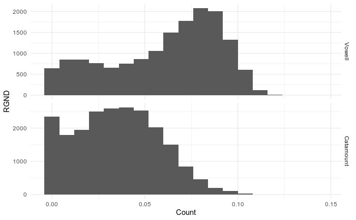

```r
raw_vals_tbl %>%
  ggplot(aes(rgnd)) +
  geom_histogram(binwidth = 0.008)+
  facet_grid(rows = vars(site %>%
                           fct_relevel("vowell") %>%
                           fct_recode("Vowell"="vowell", "Catamount"="cat")),
             scales = "free") +
  labs(x = "Count", y = "RGND") +
  theme_minimal()
```

# weather/albedo metadata

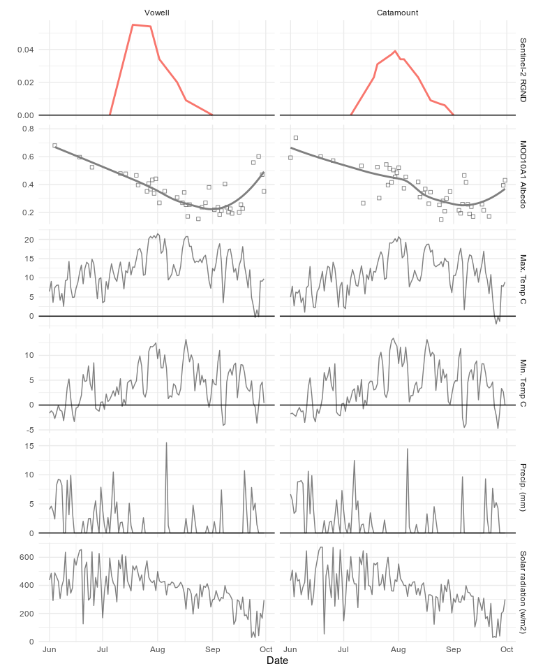

```r
wxplt
```

```r
ggsave(here("figs/wx_plot.pdf"),height =9, width = 8 )
```

# Applying G-D melt model, algae melt = 0.13 sqrt(area in cm2/l)

| site | melt |
| --- | --- |
| Vowell | 46.35784 |
| Catamount | 41.09662 |

46 cm

```r
melt(0.05)# 10.2 mm SWE/day
melt(0.039) #9 mm SWE/day
```

1 cm water over the entire bloom polygon area, is a volume of

```r
# in units of m2 and m
1.6e6*0.012 # 19,000 m3/day
2.1e6*0.009 # 19,000 m3 per day
```